# Curso R

Digamos tambem que uma das variaveis (como a altura/height) estao com unidades nao muito “favoraveis” para nossas analises. Podemos Alterar a coluna de forma a transformar seus valores ou ainda criar uma nova coluna utilizando o Verbo MUTATE. Digamos que a altura original esteja em centimetros e desejamos ver em metros:

```r
Star_2 = starwars

Star_2 %>%
    select(name,height,mass) %>%
    mutate(Altura_m = height/100)
```

| name | height | mass | Altura_m |
| --- | --- | --- | --- |
| Luke Skywalker | 172 | 77.0 | 1.72 |
| C-3PO | 167 | 75.0 | 1.67 |
| R2-D2 | 96 | 32.0 | 0.96 |
| Darth Vader | 202 | 136.0 | 2.02 |
| Leia Organa | 150 | 49.0 | 1.50 |
| Owen Lars | 178 | 120.0 | 1.78 |
| Beru Whitesun lars | 165 | 75.0 | 1.65 |
| R5-D4 | 97 | 32.0 | 0.97 |
| Biggs Darklighter | 183 | 84.0 | 1.83 |
| Obi-Wan Kenobi | 182 | 77.0 | 1.82 |

[output cut: 77 more lines]

```r
NA
NA
```

```
    Utilizando os Verbos para Respondermos Perguntas
```

Vamos agora utilizar os verbos que aprendemos para responder uma pergunta em relacao aos nossos dados:

```r
#Copiando os Resultados anteriores:

Star_2 = starwars

Star_3 = Star_2 %>%
    select(name,height,mass) %>%
    mutate(Altura_m = height/100, Massa_Kg = mass)%>%
    select(name,Altura_m,Massa_Kg)

Star_3
```

| name | Altura_m | Massa_Kg |
| --- | --- | --- |
| Luke Skywalker | 1.72 | 77.0 |
| C-3PO | 1.67 | 75.0 |
| R2-D2 | 0.96 | 32.0 |
| Darth Vader | 2.02 | 136.0 |
| Leia Organa | 1.50 | 49.0 |
| Owen Lars | 1.78 | 120.0 |
| Beru Whitesun lars | 1.65 | 75.0 |
| R5-D4 | 0.97 | 32.0 |
| Biggs Darklighter | 1.83 | 84.0 |
| Obi-Wan Kenobi | 1.82 | 77.0 |

[output cut: 77 more lines]

```r
NA
```

```r
#Calculando o IMC e ordenando de forma decrescente:

Star_3 = Star_3 %>%
    mutate(IMC = Massa_Kg/Altura_m^2)%>%
    arrange(desc(IMC))

Star_3
```

| name | Altura_m | Massa_Kg | IMC |
| --- | --- | --- | --- |
| Jabba Desilijic Tiure | 1.75 | 1358.0 | 443.42857 |
| Dud Bolt | 0.94 | 45.0 | 50.92802 |
| Yoda | 0.66 | 17.0 | 39.02663 |
| Owen Lars | 1.78 | 120.0 | 37.87401 |
| IG-88 | 2.00 | 140.0 | 35.00000 |
| R2-D2 | 0.96 | 32.0 | 34.72222 |
| Grievous | 2.16 | 159.0 | 34.07922 |
| R5-D4 | 0.97 | 32.0 | 34.00999 |
| Jek Tono Porkins | 1.80 | 110.0 | 33.95062 |
| Darth Vader | 2.02 | 136.0 | 33.33007 |

[output cut: 77 more lines]

```r
NA
```

Podemos encontrar uma introducao sobre o pacote DPLYR em:

```r
vignette("dplyr")
```

```
Basico de Graficos com GGPLOT2
```

Grafico de pontos basico:

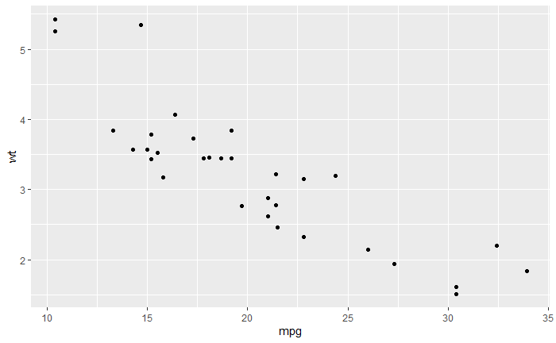

```r
library(ggthemes)
library(ggplot2)

ggplot(mtcars, aes(x = mpg,y = wt))+
    geom_point()
```

Grafico com tema “STATA”:

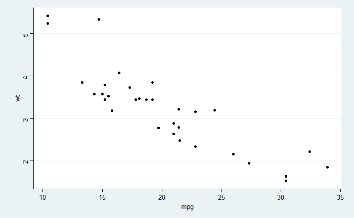

```r
library(ggthemes)
library(ggplot2)

ggplot(mtcars, aes(x = mpg,y = wt))+
    geom_point()+
    theme_stata()
```

```r
NA
NA
```

Adicionando as Legendas:

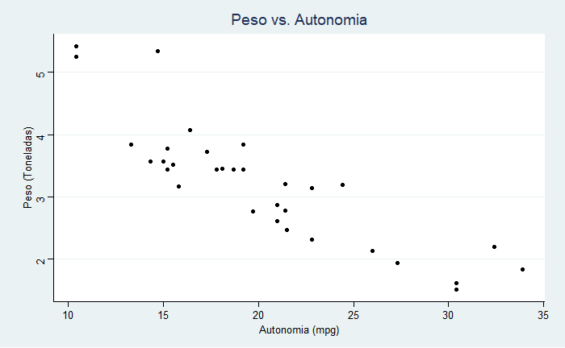

```r
ggplot(mtcars, aes(x = mpg,y = wt))+
    geom_point()+
    theme_stata()+
    labs(
        title = "Peso vs. Autonomia",
        x = "Autonomia (mpg)",
        y = "Peso (Toneladas)")
```

Colorindo os pontos em funcao de outra variavel e introduzindo uma legenda:

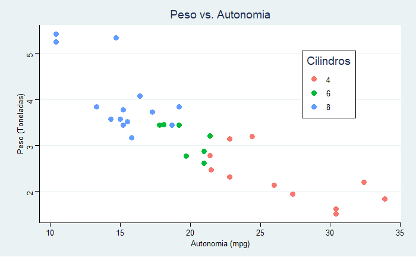

```r
#Pacotes

library(ggthemes)
library(ggplot2)

ggplot(mtcars, aes(x = mpg,y = wt, color = as.factor(cyl)))+
    geom_point(size = 3)+
    theme_stata()+
    labs(title = "Peso vs. Autonomia",
        x = "Autonomia (mpg)",
        y = "Peso (Toneladas)",
        color = "Cilindros")+
    theme(legend.position = c(0.8,0.7))
```